# Topic Modeling

Introduction to Text as Data

Amber Boydstun & Cory Struthers

April 27-29, 2023

### Introduction

Social scientists often want to understand topics in text, and how those topics vary based on characteristics of the source. In this module, we will focus on implementing two types of Latent Dirichlet Allocation (LDA) topic models: unsupervised and supervised. LDA is a Bayesian hierarchical model, or a mixed-member model, where documents can (conveniently) contain more than one topic. In other words, LDA is a probabilistic model that assumes that every document is a distribution of a fixed number of topics, and that each of those topics is a distribution of words. It is one of the most commonly used topic models in the field. The LDA model is distinctly different than dictionary approaches for categorizing documents, in part because the LDA model is estimates relationships between similar words – as opposed to using only the words the analyst provides.

In this module, we’ll need the following packages:

```r
#load libraries
require(stopwords)
require(quanteda)
require(quanteda.textmodels)
require(quanteda.textplots)
require(quanteda.textstats)
require(topicmodels)
require(seededlda)
require(ldatuning)
require(tidyverse)

options("scipen"=100, "digits"=4)

# Set working directory
setwd("/Users/cs86487/Dropbox/text-as-data-JUST-CORY-AND-AMBER/modules/data/")
getwd() # view working directory
```

### Applying unsupervised LDA model

Nonetheless, this processing may still be slow going! There are ways to handle computational intensive tasks, for instance by using the package `doParallel`, but this is beyond the scope of what we can cover in this course. We highly recommend taking advantage of parallel computing – even the minor tasks we complete in this module take considerable time. [Another less sophisticated recommendation: Run code overnight.]

As always, we will start by pre-processing the corpus, tokenizing, and creating a DFM. Recall that we could consider using tf-idf scores as opposed to word counts.

```r
# Load corpus
bills_corp = readRDS("bills_corp.RDS")

# Take small sample here
bills_corp_test = corpus_sample(bills_corp, size = 150, replace = FALSE)

# Trim corpus further to get rid of big texts
bills_corp_test$nchar = as.numeric(nchar(bills_corp_test))
bills_corp_test = corpus_subset(bills_corp_test, nchar<20000)

# Create dfm
bills_toks_test = tokens(bills_corp_test,
                         remove_punct = TRUE,
                         remove_numbers = TRUE,
                         remove_symbols = TRUE) %>%
    tokens_remove(stopwords("en"))

# Collocations
bills_toks_coll = textstat_collocations(bills_toks_test, size = 2:3, min_count = 30)
head(bills_toks_coll, 20)
```

|  | collocation | count | count_nested | length | lambda | z |
| --- | --- | --- | --- | --- | --- | --- |
| 1 | state california | 175 | 175 | 2 | 3.622 | 37.43 |
| 2 | fiscal committee | 118 | 118 | 2 | 8.139 | 36.16 |
| 3 | united states | 305 | 305 | 2 | 10.655 | 33.59 |
| 4 | pursuant section | 96 | 96 | 2 | 4.249 | 31.58 |
| 5 | key fiscal | 62 | 62 | 2 | 6.397 | 31.54 |
| 6 | existing law | 85 | 85 | 2 | 7.097 | 31.13 |
| 7 | city county | 78 | 78 | 2 | 6.866 | 31.07 |
| 8 | appropriate distribution | 74 | 74 | 2 | 7.924 | 30.11 |
| 9 | key vote | 56 | 56 | 2 | 7.332 | 29.81 |
| 10 | bill require | 66 | 66 | 2 | 5.494 | 29.56 |

[output cut: 10 more lines]

```r
# Add tokens objects together and create dfm
bills_dfm_test =  tokens_compound(bills_toks_test, bills_toks_coll, concatenator = " ") %>%
    tokens_select(padding=FALSE) %>%
    tokens_wordstem  %>%
    tokens_remove(stopwords("en")) %>%
    tokens_wordstem() %>%
    dfm() %>%
    dfm_trim(min_termfreq = 4, min_docfreq = 5)
bills_dfm_test
```

```
## Document-feature matrix of: 135 documents, 1,390 features (88.65% sparse) and 10 docvars.
##          features
## docs      ab person incom tax voluntari contribut suicid prevent law author
##   text576  1      7     7  34        18        36     21      21   1      1
##   text840  0      0     0   0         0         2      0       0   0      0
##   text896  1      7     6   0         0         0      0       0   9      1
##   text974  1      0     0   0         0         0      0       1   2      1
##   text265  0      0     0   0         0         1      0       0   0      0
##   text207  1      0     0   0         0         1      0       0   2      1
## [ reached max_ndoc ... 129 more documents, reached max_nfeat ... 1,380 more features ]
```

```r
# Explore your new matrix
topfeatures(bills_dfm_test, 30) # top 30 features
```

```
##  andwherea      shall      state california     servic     includ     provid
##        575        520        502        481        415        374        358
##    section     person  united st     requir        act     public     depart
##        351        319        305        282        279        274        274
##       fund       year    program  communiti        use     wherea      offic
##        253        249        247        236        223        221        219
##   american        day       educ        may        law   individu          b
##        209        205        205        198        191        187        187
##     nation       bill
##        178        174
```

Now that we have a DFM object, we can move on to running the LDA model. `quanteda` does not offer a function for LDA models but instead recommends using the `seededlda` package. However, there are fewer post-estimation functions available in that package, so we’ll also apply the LDA model using `topicmodels`, an alternative package with similar functionality.

Before running our model, we must define we must define the number of topics, $k$. The optimal value of $k$ depends on several considerations, all of which require human evaluation. When $k$ is too low, texts can be separated into just a few broad, substantively meaningless categories. When $k$ is too high, texts becomes divided into too many topics, some of which may conceptually overlap, be difficult to interpret, and risk overfitting.

For our initial analysis, we we’ll start with a $k$ value of 20 topics based a rough definition of policy domains (say, for instance, the number of House committees in the US House of Representatives.

After running the model, we can print the top terms associated with each topic using `terms`.

```r
# Use topicmodel pacakge
bills_ldam = LDA(bills_dfm_test, k=20, method="Gibbs", control=list(iter = 300, seed = 342, verbose = 25))
```

```
## K = 20; V = 1390; M = 135
## Sampling 300 iterations!
## Iteration 25 ...
## Iteration 50 ...
## Iteration 75 ...
## Iteration 100 ...
## Iteration 125 ...
## Iteration 150 ...
## Iteration 175 ...
## Iteration 200 ...
## Iteration 225 ...
## Iteration 250 ...
## Iteration 275 ...
## Iteration 300 ...
## Gibbs sampling completed!
```

```r
# show most likely topic
topicmodels::topics(bills_ldam) # show first 3 topics of first three texts
```

```
## text576 text840 text896 text974 text265 text207 text614 text712 text167 text226
##      16      17       5       9       4       1      14       7      14       8
## text271 text137 text481 text789 text807 text552 text622 text103 text574 text828
##      11       6       8       4       5       7      11       5      11      15
## text821 text894 text911 text889 text488 text193 text865 text735 text555  text67
##      18      13      12       1       6      13      10      14      13       4
## text150 text423 text953 text955 text713 text740 text623 text473 text231 text848
##       7      13      14      15      17      13      17      11      17       3
##  text51 text836 text758 text153 text631 text629 text981 text533 text138 text644
##      17      13       2       7       7      17       4       4       6       5
## text179 text619 text413 text472 text114 text870 text320 text282 text195 text725
##      13       4      14       6       4       1       7       7      13      17
##  text72 text905 text801 text759 text721 text734 text335  text48 text319 text351
##      16      19       4      17      14       4      17       8      16      14
##  text64 text113 text274 text362 text658 text395 text630 text101 text163 text300
##      20       9      14      10      17      19      15      18      17      12
## text669 text868 text297 text673 text498 text439  text59 text407 text435 text753
##      14       7       4       4       7       7      10       4      11      15
## text714 text121 text539 text949 text643 text932 text263 text408 text454  text13
##      17       9      12      17       7      12       5       7       4      20
## text822 text977  text50 text135  text82 text729 text971  text49 text861 text259
##      14      14       4      16      10       9       9      13      15       2
## text128 text202 text239 text349 text794 text191 text200 text526  text97 text175
##      14       5      15       5       3      19       6       5      14       2
## text285 text369 text348  text77 text339 text989 text229 text730 text557 text459
##      19      12      14       6       6       4      14       4      13      11
## text324  text23 text405 text276 text243
##      19       1       7      13      16
```

```r
# Show most frequently used terms in each topic
topicmodels::terms(bills_ldam, 15)
```

```
##       Topic 1      Topic 2      Topic 3      Topic 4     Topic 5     Topic 6
##  [1,] "fund"       "offic"      "project"    "american"  "shall"     "well"
##  [2,] "veteran"    "member"     "energi"     "celebr"    "section"   "commiss"
##  [3,] "depart"     "public"     "cost"       "andwherea" "requir"    "state"
##  [4,] "state"      "inform"     "governor"   "african"   "b"         "public"
##  [5,] "annual"     "repr"       "leadership" "day"       "provid"    "resourc"
##  [6,] "facil"      "data"       "requir"     "right"     "act"       "divi"
##  [7,] "univ"       "one"        "certifi"    "women"     "c"         "program"
##  [8,] "benefit"    "california" "resourc"    "year"      "may"       "access"
##  [9,] "part"       "state"      "public"     "freedom"   "specifi"   "impact"
## [10,] "california" "particip"   "agenc"      "histori"   "bill"      "oper"
## [11,] "money"      "council"    "oper"       "peopl"     "provi"     "studi"
## [12,] "feder"      "legislatur" "altern"     "united st" "follow"    "land"
## [13,] "act"        "engag"      "environ"    "contribut" "d"         "depart"
## [14,] "general"    "polici"     "applic"     "nation"    "paragraph" "test"
```

[output cut: 49 more lines]

### Validating unsupervised LDA model

Before we get too excited about the output, we first need to consider $k$. How do we know if we’ve assigned the “right” number of topics? The good news is that there are several metrics to evaluate the answer to this question. The bad news is that no single metric is definitive, and there’s no guarantee that all metrics will point the same direction – thus, the importance of human judgement. Other good news includes that the field is evolving, and evolving toward better metrics and guideposts.

We’ll present several metrics (not exhaustive list) in this module; please also note there are metrics to evaluate model fit that we do not focus on in this module. The first metric we’ll show you comes from the `ldatuning` package, which offers four distinct metrics for analyzing `k`. These metrics can be applied in a single function `FindTopicsNumber`.

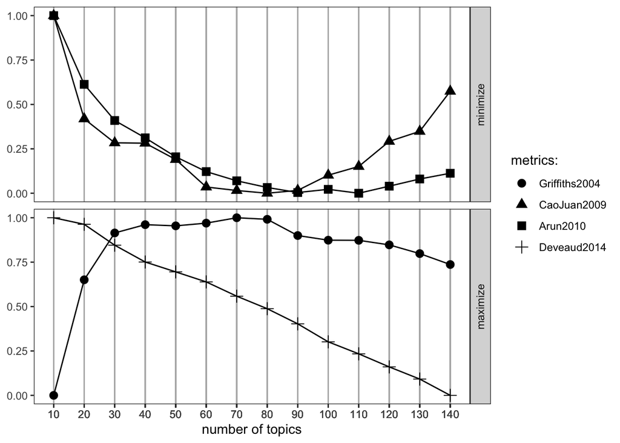

```r
# Evaluate k
numTopics = FindTopicsNumber(bills_dfm_test,
                             topics = seq(10, 140, by = 10),
                             metrics=c("Griffiths2004", "CaoJuan2009", "Arun2010","Deveaud2014"))

# View individual metric across specified k
numTopics$Arun2010

# Plot topics across metrics
FindTopicsNumber_plot(numTopics)
```

To compare, we’ll evaluate perplexity on the same values of $k$ we assigned when we applied metrics in the `ldatuning` package.

```r
# Assign k topics
k_topics_eval =  c(10,20,30,40,50,60,70,80,90,100,110,120,130,140)

# Create folding sets
folding_sets = rep(1:5, each = 26) # 130 bills / 5 sets

# Function that estimates perplexity across k and folding sets
getPerplexity = function(k, fold) {

    testing.dtm = which(folding_sets == fold) # 1/5 fold
    training.dtm = which(folding_sets != fold) # rest of the data

    training.model = LDA(bills_dfm_test[training.dtm, ], k = k) # why wouldn't we train on smaller set and test on larger
    test.model = LDA(bills_dfm_test[testing.dtm, ], model = training.model, control = list(estimate.beta = FALSE))

    perplexity(test.model)
}

# Create results object
perplexity_results = NULL

# Fill results object using function
for (k in c(10,20,30,40,50,60,70,80,90,100,110,120,130,140)) {
    for (fold in 1:5) {
        perplexity_results = rbind(perplexity_results,
                                   c(k, fold, getPerplexity(k, fold)))
    }
}

# Transform to df
perplexity_results = as.data.frame(perplexity_results)
colnames(perplexity_results) = c("k", "fold", "perplexity_value")
perplexity_results
```

| k | fold | perplexity_value |
| --- | --- | --- |
| 10 | 1 | 750.0 |
| 10 | 2 | 763.5 |
| 10 | 3 | 759.8 |
| 10 | 4 | 765.2 |
| 10 | 5 | 696.7 |
| 20 | 1 | 715.1 |
| 20 | 2 | 732.2 |
| 20 | 3 | 728.9 |
| 20 | 4 | 732.2 |
| 20 | 5 | 669.4 |

[output cut: 60 more lines]

The dataframe includes three columns: one for topic $k$, one for the fold in which we tested our trained data, and finally a column for the perplexity value. We can summarize the output in two ways. First, we can average the perplexity estimate for each $k$ across all five folds. We can then plot the trend line.

```r
# Round the folds
perplexity_sum = perplexity_results %>%
      group_by(k) %>%
    summarise(average_perplexity = mean(perplexity_value))
perplexity_sum
```

| k | average_perplexity |
| --- | --- |
| 10 | 747.0 |
| 20 | 715.6 |
| 30 | 687.9 |
| 40 | 658.8 |
| 50 | 647.9 |
| 60 | 647.3 |
| 70 | 624.0 |
| 80 | 614.9 |
| 90 | 608.0 |
| 100 | 609.7 |

[output cut: 4 more lines]

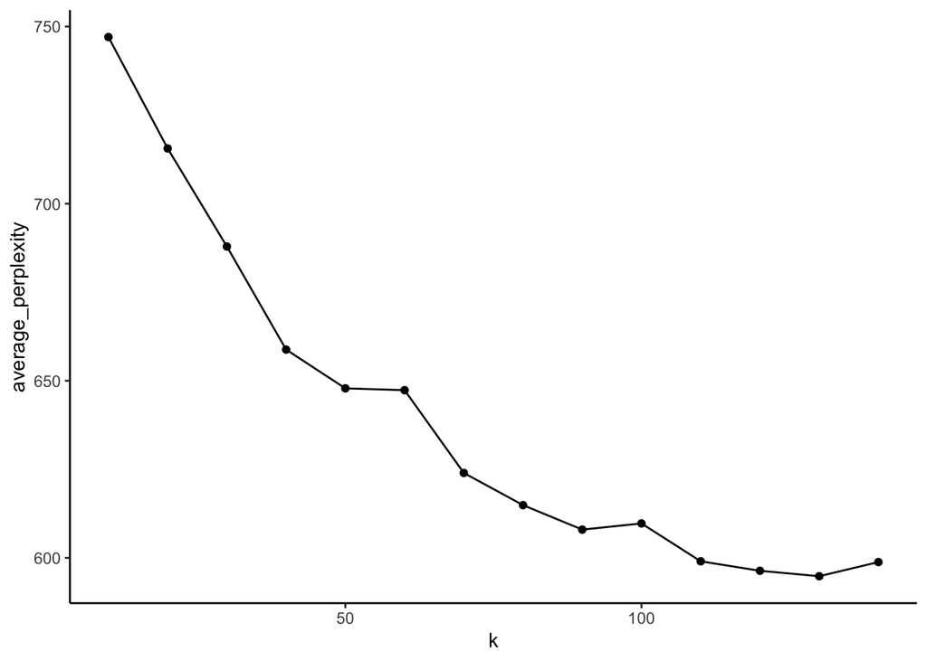

```r
# Plot perplexity across groups
ggplot(perplexity_sum, aes(x=k, y=average_perplexity)) +
  geom_point() +
  geom_line() +
  theme_classic()
```

The results look a little different based on the trend line. If we follow the principle of choosing the minimum value in which a leveling off occurs, we’re much closer to 100 topics. Before addressing how this output influences decisions regarding $k$, let’s plot each fold instead of collapsing them in order to see the extent of variation.

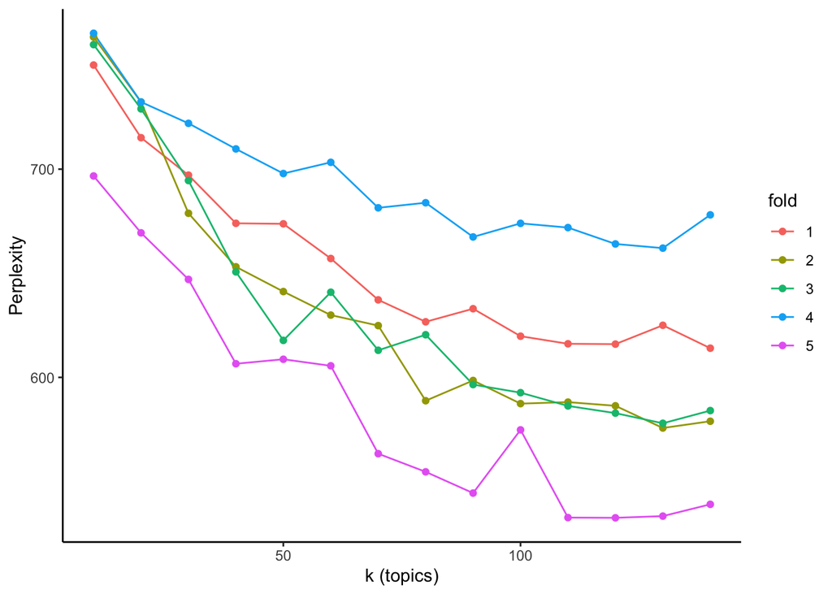

```r
# Plot folds across groups
perplexity_results$fold = as.character(perplexity_results$fold)
ggplot(perplexity_results) +
  geom_line(aes(x=k, y=perplexity_value, group=fold, color=fold)) +
  geom_point(aes(x=k, y=perplexity_value, group=fold, color=fold)) +
  theme_classic() +
  xlab("k (topics)") +
  ylab("Perplexity")
```

```r
  scale_color_manual(values = c('Red', 'Orange', 'Blue', 'Green', 'Purple'))
```

[output not shown]

Evaluating whether 30-50 topics best represent the topical distribution across our text requires – you guessed it (again) – human eyes. “Best practices” on topic models are loosely assembled, but we would implement something like the following in our own work (based on Grimmer et al., 2021 among others):

- Running the topic model at 30, 40, and 50 topics and examining the topics for substantive meaning and coherence (step 1).
- Review associated terms and some texts, which may rule out a $k$ rather quickly.*
- Once settled on a set of topics that seem to meet the criteria of substantive meaning and coherence, take a random sample of the text and using a clear procedure for closely reading and validating topics by hand across that sample. Now we have come full circle to manual content analysis!

*Of course, sampling a large text across many topics that vary in distribution across each document is no easy feat. One helpful “shortcut” to begin human validation is taking several documents with the highest proportion of a given topic and reading its text. If even the most “topic-y” topic documents do not seem to describe the text well, it’s a strong signal that the model isn’t explaining the topical distribution well.

Let’s reapply our LDA topic model with 40 topics.

```r
# Apply model with 40 topics
bills_ldam_40 = LDA(bills_dfm_test, k=40, method="Gibbs", control=list(iter = 300, seed = 342, verbose = 25))
```

```
## K = 40; V = 1390; M = 135
## Sampling 300 iterations!
## Iteration 25 ...
## Iteration 50 ...
## Iteration 75 ...
## Iteration 100 ...
## Iteration 125 ...
## Iteration 150 ...
## Iteration 175 ...
## Iteration 200 ...
## Iteration 225 ...
## Iteration 250 ...
## Iteration 275 ...
## Iteration 300 ...
## Gibbs sampling completed!
```

```r
# Show most frequently used terms in each topic
topicmodels::terms(bills_ldam_40, 15)
```

```
##       Topic 1      Topic 2      Topic 3      Topic 4    Topic 5
##  [1,] "veteran"    "member"     "project"    "includ"   "andwherea"
##  [2,] "depart"     "inform"     "governor"   "employ"   "california"
##  [3,] "benefit"    "state"      "leadership" "disabl"   "day"
##  [4,] "feder"      "offic"      "applic"     "condit"   "celebr"
##  [5,] "annual"     "data"       "environ"    "individu" "year"
##  [6,] "state"      "california" "certifi"    "life"     "communiti"
##  [7,] "fund"       "council"    "public"     "limit"    "new"
##  [8,] "legislatur" "one"        "chapter"    "disord"   "___________________"
##  [9,] "affair"     "repr"       "altern"     "mental"   "agricultur"
## [10,] "california" "develop"    "requir"     "race"     "mani"
## [11,] "increa"     "public"     "agenc"      "associ"   "recogn"
## [12,] "counti"     "agenc"      "lead"       "function" "throughout"
## [13,] "budget"     "appoint"    "determin"   "medic"    "world"
## [14,] "million"    "depart"     "emiss"      "activ"    "first"
```

[output cut: 129 more lines]

Do we think these topics look more substantively meaningful and coherent, more so than 20 topics? Below, we grab 3 documents with the highest proportion of each topic to read and annotate. Note that because we have few documents in this test example, we have few documents with high probability of being about a given topic. This would change with more data.

Nonetheless, remember that one of the greatest challenges in unsupervised topic modeling is discovering what these unnamed topics represent.

```r
# Estimate for each bill
topic_dist = as.data.frame(posterior(bills_ldam_40)[2])
topic_dist$doc_id = row.names(topic_dist)
head(topic_dist)
```

|  | topics.1 | topics.2 | topics.3 | topics.4 | topics.5 | topics.6 | topics.7 | topics.8 | topics.9 | topics.10 | topics.11 | topics.12 | topics.13 | topics.14 | topics.15 | topics.16 | topics.17 | topics.18 | topics.19 | topics.20 | topics.21 | topics.22 | topics.23 | topics.24 | topics.25 | topics.26 | topics.27 | topics.28 | topics.29 | … |
| --- | --- | --- | --- | --- | --- | --- | --- | --- | --- | --- | --- | --- | --- | --- | --- | --- | --- | --- | --- | --- | --- | --- | --- | --- | --- | --- | --- | --- | --- | --- |
| text576 | 0.005952 | 0.005952 | 0.003151 | 0.004552 | 0.001751 | 0.005952 | 0.003151 | 0.001751 | 0.003151 | 0.004552 | 0.001751 | 0.003151 | 0.001751 | 0.008754 | 0.001751 | 0.003151 | 0.700630 | 0.008754 | 0.001751 | 0.003151 | 0.001751 | 0.141807 | 0.010154 | 0.012955 | 0.004552 | 0.003151 | 0.001751 | 0.004552 | 0.001751 | … |
| text840 | 0.008755 | 0.004864 | 0.012646 | 0.016537 | 0.362840 | 0.004864 | 0.008755 | 0.004864 | 0.032101 | 0.117704 | 0.012646 | 0.016537 | 0.004864 | 0.004864 | 0.004864 | 0.004864 | 0.004864 | 0.004864 | 0.004864 | 0.004864 | 0.004864 | 0.008755 | 0.004864 | 0.004864 | 0.004864 | 0.156615 | 0.012646 | 0.020428 | 0.024319 | … |
| text896 | 0.040466 | 0.002772 | 0.002772 | 0.004989 | 0.004989 | 0.002772 | 0.004989 | 0.002772 | 0.027162 | 0.004989 | 0.024945 | 0.002772 | 0.002772 | 0.009424 | 0.002772 | 0.004989 | 0.004989 | 0.004989 | 0.009424 | 0.002772 | 0.031596 | 0.182373 | 0.299889 | 0.064856 | 0.016075 | 0.004989 | 0.009424 | 0.007206 | 0.044900 | … |
| text974 | 0.003061 | 0.007143 | 0.011224 | 0.001701 | 0.001701 | 0.003061 | 0.004422 | 0.003061 | 0.003061 | 0.001701 | 0.008503 | 0.004422 | 0.001701 | 0.003061 | 0.001701 | 0.004422 | 0.005782 | 0.626190 | 0.008503 | 0.001701 | 0.005782 | 0.140476 | 0.072449 | 0.005782 | 0.001701 | 0.003061 | 0.003061 | 0.001701 | 0.008503 | … |
| text265 | 0.007576 | 0.005245 | 0.002914 | 0.007576 | 0.035548 | 0.002914 | 0.005245 | 0.007576 | 0.007576 | 0.002914 | 0.002914 | 0.002914 | 0.005245 | 0.002914 | 0.709207 | 0.007576 | 0.009907 | 0.005245 | 0.012238 | 0.044872 | 0.005245 | 0.002914 | 0.002914 | 0.005245 | 0.005245 | 0.007576 | 0.002914 | 0.002914 | 0.002914 | … |
| text207 | 0.713806 | 0.003358 | 0.010821 | 0.003358 | 0.001866 | 0.001866 | 0.004851 | 0.004851 | 0.006343 | 0.004851 | 0.007836 | 0.006343 | 0.004851 | 0.001866 | 0.003358 | 0.004851 | 0.006343 | 0.001866 | 0.001866 | 0.003358 | 0.003358 | 0.080970 | 0.021269 | 0.003358 | 0.001866 | 0.004851 | 0.003358 | 0.006343 | 0.001866 | … |

```r
# Transform to long
topic_dist_long = topic_dist %>%
  pivot_longer(!doc_id, names_to = "topic", values_to = "Topic distribution")

# Get highest value by topic
highest_prop = topic_dist_long %>%
  group_by(topic, doc_id) %>%
  summarise(max = max(`Topic distribution`))
highest_prop
```

| topic | doc_id | max |
| --- | --- | --- |
| topics.1 | text101 | 0.0094034 |
| topics.1 | text103 | 0.0102273 |
| topics.1 | text113 | 0.0374618 |
| topics.1 | text114 | 0.0082117 |
| topics.1 | text121 | 0.0030941 |
| topics.1 | text128 | 0.0109223 |
| topics.1 | text13 | 0.0037879 |
| topics.1 | text135 | 0.0152174 |
| topics.1 | text137 | 0.0058685 |
| topics.1 | text138 | 0.0044410 |

[output cut: 5390 more lines]

```r
highest_prob = topic_dist_long %>%
  arrange(desc(`Topic distribution`)) %>%
  group_by(topic) %>%
  slice(1:3)
highest_prob
```

| doc_id | topic | Topic distribution |
| --- | --- | --- |
| text207 | topics.1 | 0.71381 |
| text889 | topics.1 | 0.71082 |
| text50 | topics.1 | 0.08940 |
| text488 | topics.10 | 0.62292 |
| text259 | topics.10 | 0.25940 |
| text840 | topics.10 | 0.11770 |
| text285 | topics.11 | 0.63417 |
| text324 | topics.11 | 0.16827 |
| text905 | topics.11 | 0.15830 |
| text138 | topics.12 | 0.62618 |

[output cut: 110 more lines]

```r
# Start reading/annotating
as.character(bills_corp[975]) # 0.63 topic 8
```

```
##                                                                                                                                                                                                                                                                                                          …
## "sb 884, as amended, dodd.\n                          education finance: emergencies: public safety power shutoffs.existing law prohibits a school district from receiving a state apportionment based upon average daily attendance unless it has maintained the regular day schools of the district for…
```

```r
as.character(bills_corp[191]) # 0.59 topic 8
```

```
##                                                                                                                                                                                                                                                                                                          …
## "ab 2651, as amended, megan dahle.\n                          school finance: necessary small schools.existing law requires, for each school district that includes a necessary small school, as defined, in the current or prior fiscal year, the superintendent of public instruction to compute a spec…
```

### Starter material for distributions and visualization

There are many creative ways to view the distribution of topics over texts once the model is adjusted and validated. For instance, we can attach the most likely topics for each text (i.e., the topic with the greatest likelihood for that document), assign those to the corpus, and examine the distribution over the corpus. Likewise, we can observe the distribution of the three top 3 probabilities of each topic, which can help us evaluate the extent to which the model estimates mixed-member patterns or a single topic.

```r
# Most likely topics for each bill
head(topicmodels::topics(bills_ldam_40), 20)
```

```
## text576 text840 text896 text974 text265 text207 text614 text712 text167 text226
##      17       5      23      18      15       1      30      27      28      16
## text271 text137 text481 text789 text807 text552 text622 text103 text574 text828
##      36      12      16       7      21      27      21      23      33      29
```

```r
# Assign most likely topic to docvars
bills_corp_test$most_likely_topic = topicmodels::topics(bills_ldam_40)

# View distribution
table(bills_corp_test$most_likely_topic)
```

```
##
##  1  2  3  4  5  6  7  8  9 10 11 12 13 14 15 16 17 18 19 20 21 23 24 25 26 27
##  2  1  1  1 11  2  6  3  2  2  2  2  7  4  4  2  1  3  4  2  3  5  4  2  2  3
## 28 29 30 31 32 33 34 35 36 37 38 39 40
##  6  6  8  8  2  2  3  4  2  2  2  1  8
```

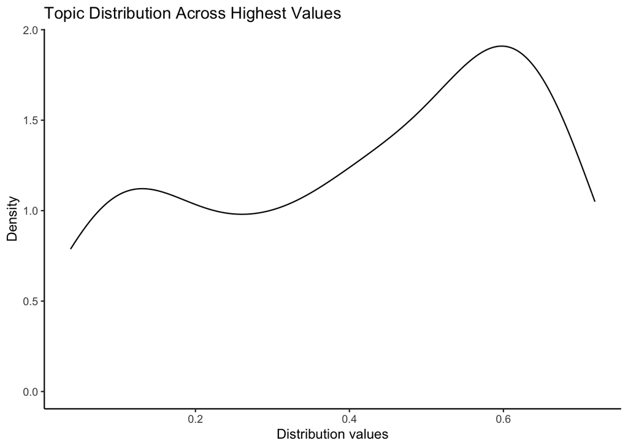

```r
# Plot
ggplot(highest_prob, aes(x=`Topic distribution`)) +
  geom_density(alpha = 0.2) +
  theme_classic() +
  xlab("Distribution values") +
  ylab("Density") +
  ggtitle("Topic Distribution Across Highest Values")
```

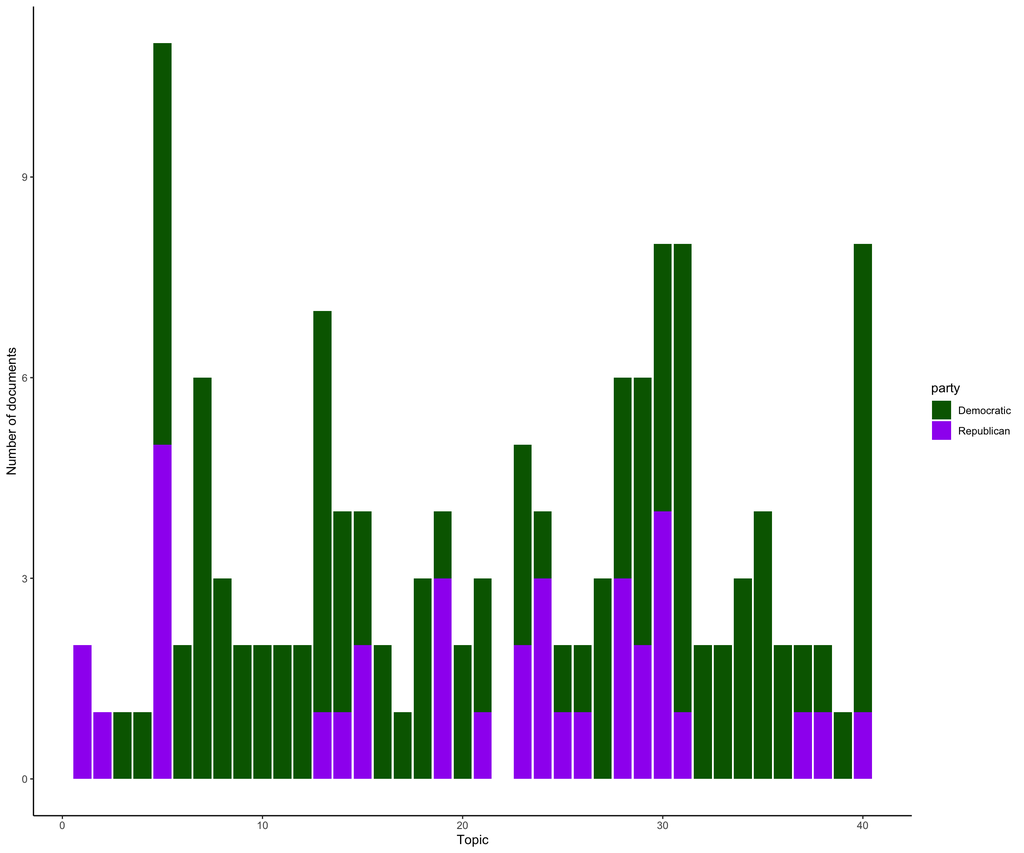

```r
# Topic count by party
bills_docvars_df = docvars(bills_corp_test)
top_topic_party = count(bills_docvars_df, party, most_likely_topic)

# Plot
ggplot(top_topic_party, aes(most_likely_topic, n)) +
  geom_col(aes(fill=party)) +
  theme_classic() +
  ylab("Number of documents") +
  xlab("Topic") +
  scale_fill_manual(values = c("darkgreen", "purple"))
```

**Question 1 (BREAKOUT). Using the the data file “sample_news_1995-2017.csv”, Apply an LDA model with $k$ topics to the news sample dataframe (sample_news_1995-2017.csv). Assign the first $k$ based on your intuition and human judgement. View the terms associated. Are those topics substantively meaningful and coherent? Now, use the validation procedures we used to estimate the number of topics.**

### Apply supervised (seeded) LDA

Now, we will briefly cover one of two semi-supervised approaches to topic modeling. One of them is Structural Topic Modeling (STM), which is beyond the scope of what we can expound in a short intensive introductory TAD class. Interested students can visit the `stm` package and use the slides to gain initial insight into the `stm` approach.

The second approach is to “seed” an LDA model with terms known to represent a topic, which the model uses to identify related words and phrases. Here, the analyst not assigns $k$ but also *defines* the content within $k$.

Below, we use the dictionary terms from the policy agendas dictionary to “seed” the LDA model on the same dfm object regarding California legislative bills. A key difference between the LDA approach and the dictionary approach is that the LDA models “learns” which words are related to those seed words and uses that information to determine topics within documents.

As opposed to using all the possible seed words in the policy agendas dictionary, we take the first 10. Seeding with too many terms is not really seeding but pre-determining, and may risk overfitting the model.

Note that here we’re using the `seededlda` package quanteda recommends.

```r
# Get policy agendas dictionary
load("policy_agendas_english.RData")
head(dictLexic2Topics)
names(dictLexic2Topics)

# Take first ten features of policy agendas dictionary
policy_seeds = lapply(dictLexic2Topics,head,10)
policy_seeds[1:2]
names(policy_seeds)

# Create dictionary to seed with
policy_seeds_dict = dictionary(policy_seeds)

# Apply *seeded* lda
bills_lda_seed = textmodel_seededlda(bills_dfm_test, dictionary = policy_seeds_dict, max_iter = 2000)
  # Note "residual topics" option
  # Note need for multiple runs (separate from iterations)

# View terms
terms(bills_lda_seed, 15)

# Create topic distribution
all_topics = as_tibble(bills_lda_seed$theta, rownames = "doc_id")
```

[output not shown]

The first thing to do is ask ourselves if the seed terms sufficiently capture the topics we intend. Let’s be more intentional about our construction of the seed terminology and evaluate whether this improves topical output.

```r
# Select most prominent seed words associated with topic
policy_seeds_dict_revised = dictionary(list(macroeconomics = c("fiscal", "taxes", "inflation", "microecon", "macroecon", "deficit"),
                                            civil_rights = c("civil right", "civil libert", "diversity", "gay", "racism", "sexism"),
                                            healthcare = c("health", "primary care", "prescription", "medicine", "physician"),
                                            agriculture = c("agricult", "pesticide", "tractor", "farm", "crop"),
                                            forestry = c("forest", "lumber", "timber", "tree", "deforest"),
                                            labour = c("hiring", "employ", "wage", "worker", "retirement", "unioniz"),
                                            immigration  = c("immigra", "border", "citizenship", "asylum", "deport"),
                                            education  = c("educat", "graduate", "student", "tuition"),
                                            environment = c("environment", "climate change", "global warming", "greenhouse gas"),
                                            energy = c("electric", "energy", "oil produc", "natural gas", "renewable"),
                                            fisheries = c("fish", "crab", "mollusk", "aquaculture"),
                                            transportation = c("transport", "travel", "car", "road", "airline", "subway"),
                                            crime = c("crime", "felon", "incarcerat", "gun control", "indict", "criminal"),
                                            social_welfare = c("pension", "low-income", "poverty", "food bank"),
                                            housing = c("mortgage", "housing", "homeless", "real estate"),
                                            finance = c("banks", "copyright", "small business", "credit card"),
                                            defence = c("army", "militar", "troop", "war", "weapon"),
                                            sstc = c("scienc", "technolog", "telecom", "meterolog"),
                                            foreign_trade = c("export", "free-trade", "wto", "tariff"),
                                            intl_affairs = c("diplomacy", "passport", "ambassador", "embass", "foreign aid"),
                                            government_ops = c("mail", "postal", "public sector", "civil service"),
                                            land_water_management = c("dams", "forest management", "mining", "water resource"),
                                            culture = c("art", "entertain", "theater"),
                                            prov_local = c("land use", "local government", "municipal", "zoning"),
                                            intergovernmental = c("intergovernment", "equalization"),
                                            # constitutional_natl_unity = c("constitution", "federalis"),
                                            aboriginal = c("amerindian", "native american", "first nation"),
                                            religion = c("christian", "catholic", "prayer", "god", "allah")))

# Apply model
bills_lda_seed_update = textmodel_seededlda(bills_dfm_test, dictionary = policy_seeds_dict_revised, max_iter = 2000)

# Get terms
terms(bills_lda_seed_update, 15)
```

**Question 2 (BREAKOUT). Now apply the seeded LDA model to the news sample dataframe (sample_news_1995-2017.csv), either using the policy agendas dictionary or developing your own policy seed dictionary. After running the model, compare the two outputs and a sample of text. Does the unsupervised or supervised learning approach lead to more substantively meaningful and coherent topics?**